# IODS course project

Henna Karhapää

# Introduction to Open Data Science - Course Project

# About the project

I am very interested to learn R better as my current expertise is at an intro level. Also, a bit overwhelmed with all the different platforms, codes and functions in R. Hopefully, things get easier as I make progress with the course and maybe there are some similarities in the functionality of R with other tools that I am more familiar with.

The R for Health Data Science and the Exercise 1 provide quite a good learning tool given clear explanations and learning-by-doing approach. The functionality of R with building different kind of graphs seems very useful compared to some other tools. The first four chapters of the book provide a good basics of using R, but I am particularly interested to make progress towards more analytical work with R.

Link to Github: https://github.com/Henna2023/IODS-project

```r
# This is a so-called "R chunk" where you can write R code.

date()
```

```
## [1] "Mon Dec 11 18:04:15 2023"
```

The text continues here.

# Chapter 2: Regression and model validation

Each step of the assignment 2 is detailed below in the code section below.

```r
# Part 1 of Assignment 2

# Reading the data file from the url link
students2014 <- read.table("https://raw.githubusercontent.com/KimmoVehkalahti/Helsinki-Open-Data-Science/master/datasets/learning2014.txt", sep = ",", header = T)

# Checking the dimensions and structure of the dataset
dim(students2014)
```

```
## [1] 166   7
```

```r
str(students2014)
```

```
## 'data.frame':    166 obs. of  7 variables:
##  $ gender  : chr  "F" "M" "F" "M" ...
##  $ age     : int  53 55 49 53 49 38 50 37 37 42 ...
##  $ attitude: num  3.7 3.1 2.5 3.5 3.7 3.8 3.5 2.9 3.8 2.1 ...
##  $ deep    : num  3.58 2.92 3.5 3.5 3.67 ...
##  $ stra    : num  3.38 2.75 3.62 3.12 3.62 ...
##  $ surf    : num  2.58 3.17 2.25 2.25 2.83 ...
##  $ points  : int  25 12 24 10 22 21 21 31 24 26 ...
```

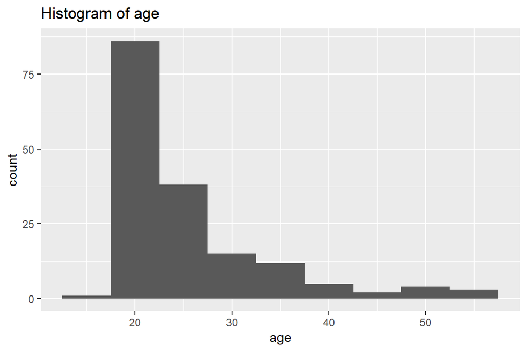

```r
#There are 166 observations of 7 variables (gender, age, attitude, deep, stra, surf and points) in the data set.
# - Gender is a character F (female) or M (male)
# - Age and points are integers
# - Attitude, deep, stra and surf are numbers




#Part 2 of Assingment 2

# Access the gglot2 library
library(ggplot2)

# Taking a visual look at the data by plotting histograms of each variable except gender which is a character

ggplot(students2014, aes(x = age)) +
  geom_histogram(binwidth = 5) +
  ggtitle("Histogram of age")
```

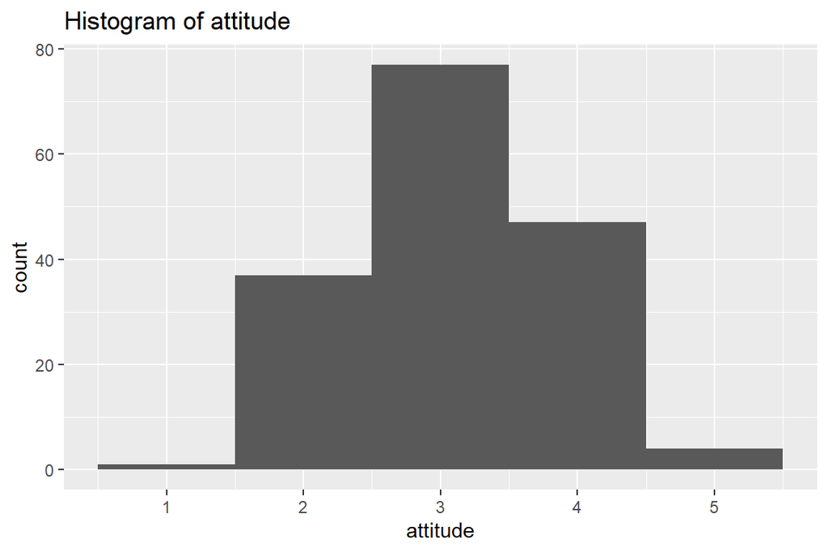

```r
ggplot(students2014, aes(x = attitude)) +
  geom_histogram(binwidth = 1) +
  ggtitle("Histogram of attitude")
```

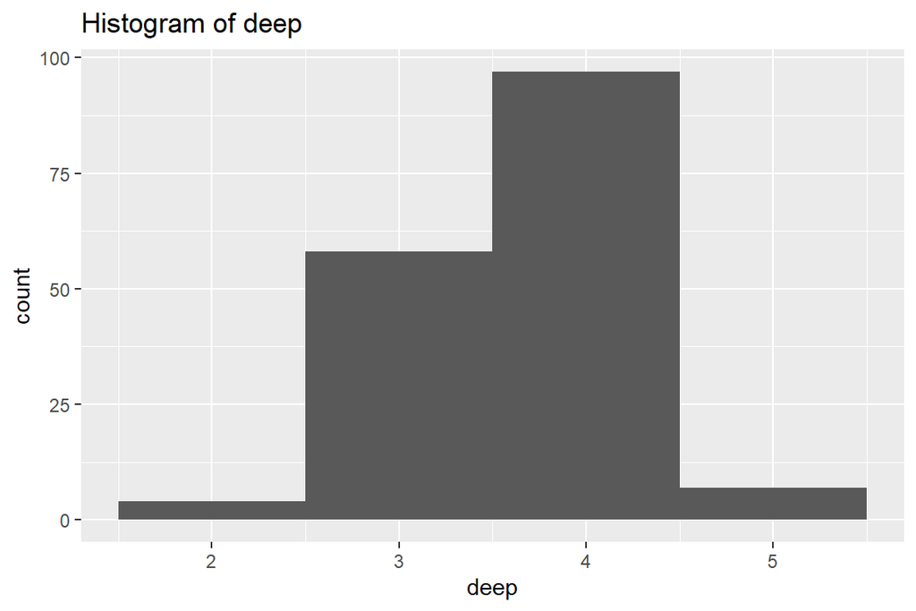

```r
ggplot(students2014, aes(x = deep)) +
  geom_histogram(binwidth = 1) +
  ggtitle("Histogram of deep")
```

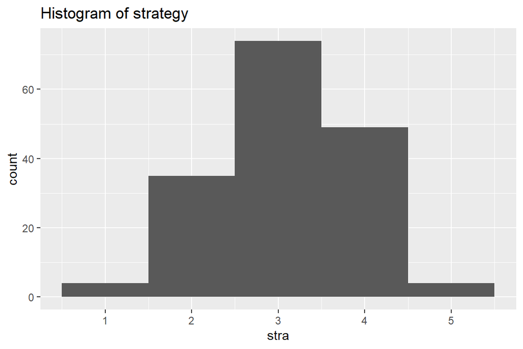

```r
ggplot(students2014, aes(x = stra)) +
  geom_histogram(binwidth = 1) +
  ggtitle("Histogram of strategy")
```

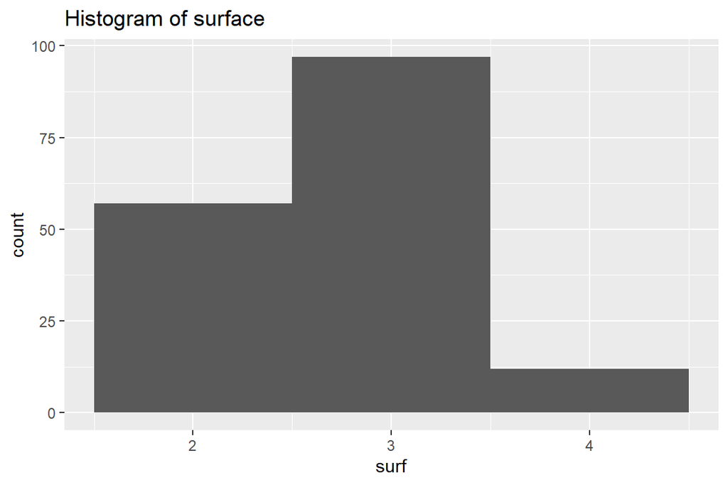

```r
ggplot(students2014, aes(x = surf)) +
  geom_histogram(binwidth = 1) +
  ggtitle("Histogram of surface")
```

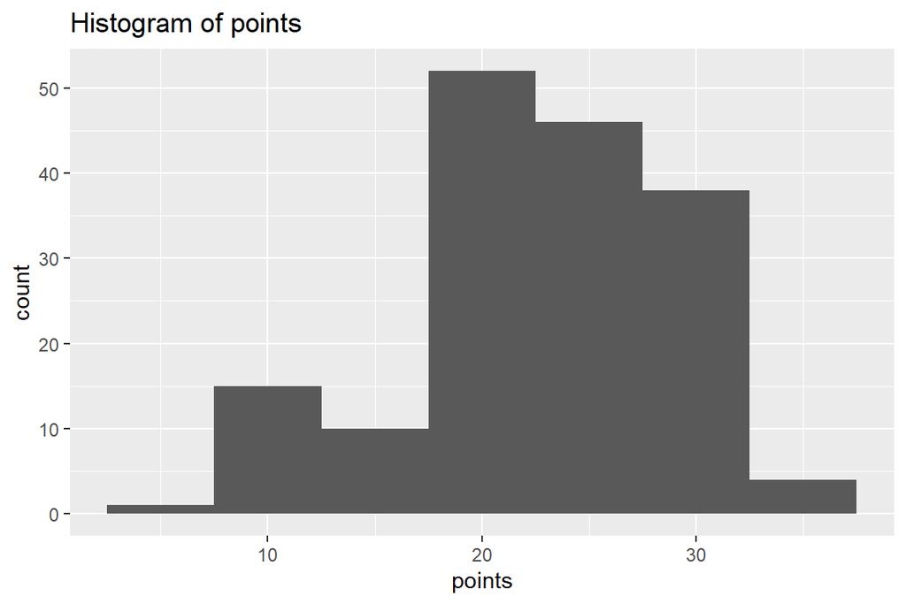

```r
ggplot(students2014, aes(x = points)) +
  geom_histogram(binwidth = 5) +
  ggtitle("Histogram of points")
```

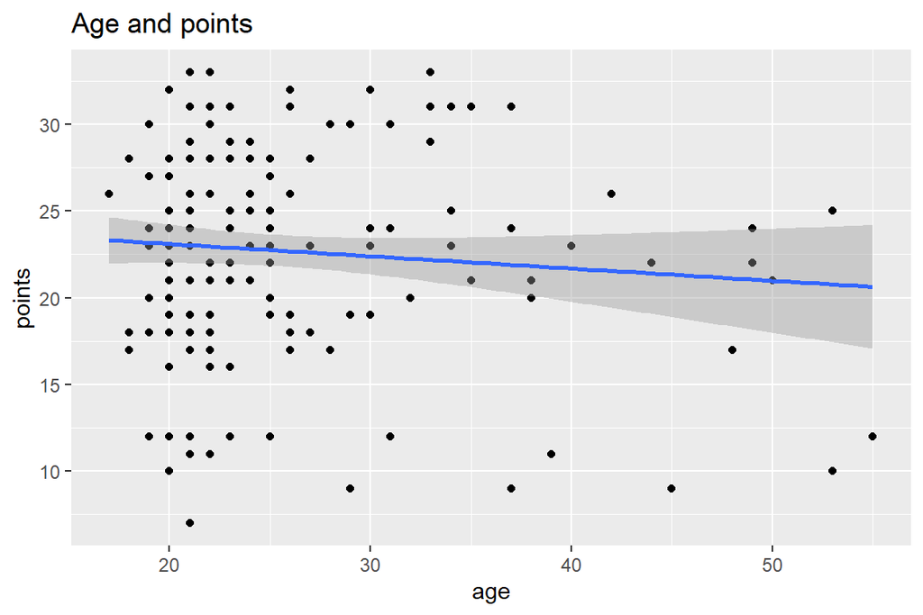

```r
# Adding plots of each pair to look at the relation of different variables. Regression lines are added to the plots to visualize the relation.

ggplot(students2014, aes(x = age, y = points)) +
  geom_point() +
  geom_smooth(method = "lm") +
  ggtitle("Age and points")
```

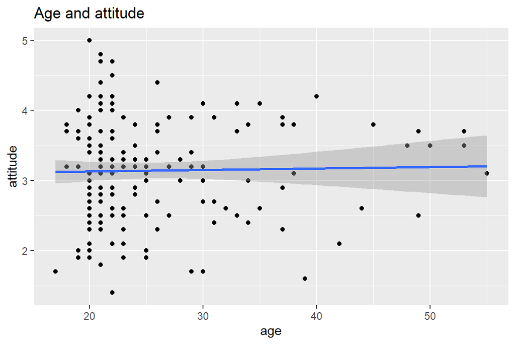

```r
ggplot(students2014, aes(x = age, y = attitude)) +
  geom_point() +
  geom_smooth(method = "lm") +
  ggtitle("Age and attitude")
```

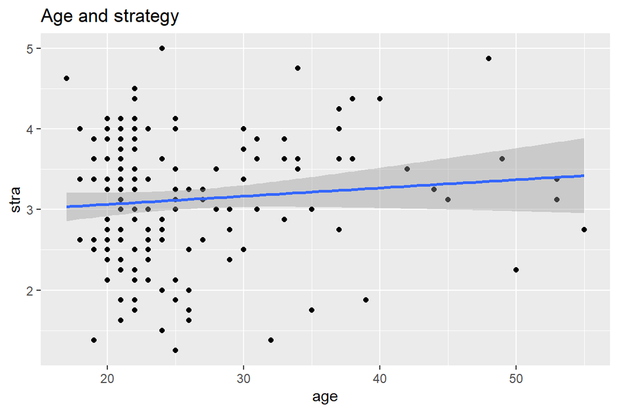

```r
ggplot(students2014, aes(x = age, y = stra)) +
  geom_point() +
  geom_smooth(method = "lm") +
  ggtitle("Age and strategy")
```

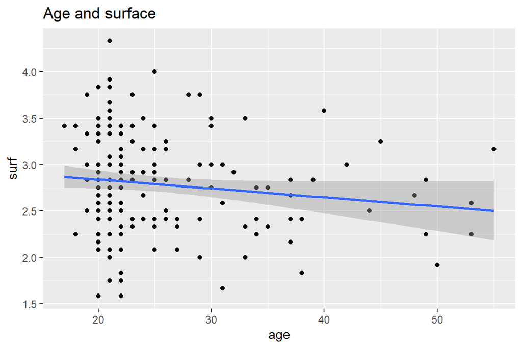

```r
ggplot(students2014, aes(x = age, y = surf)) +
  geom_point() +
  geom_smooth(method = "lm") +
  ggtitle("Age and surface")
```

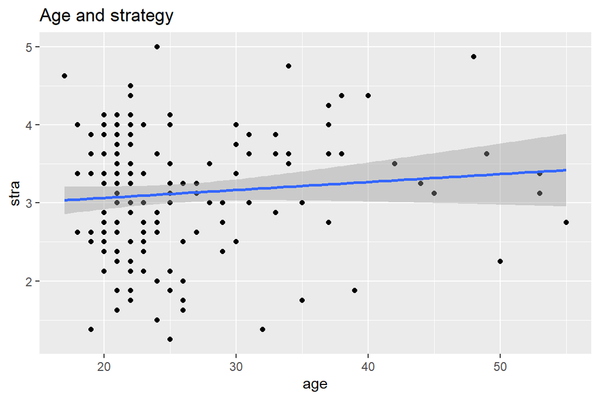

```r
ggplot(students2014, aes(x = age, y = stra)) +
  geom_point() +
  geom_smooth(method = "lm") +
  ggtitle("Age and strategy")
```

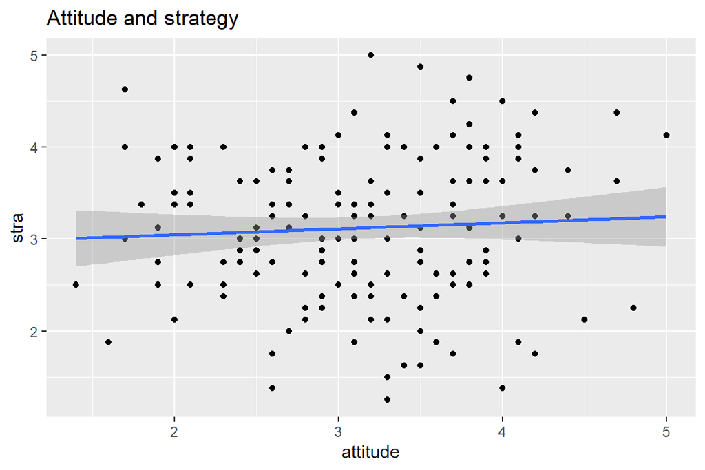

```r
ggplot(students2014, aes(x = attitude, y = stra)) +
  geom_point() +
  geom_smooth(method = "lm") +
  ggtitle("Attitude and strategy")
```

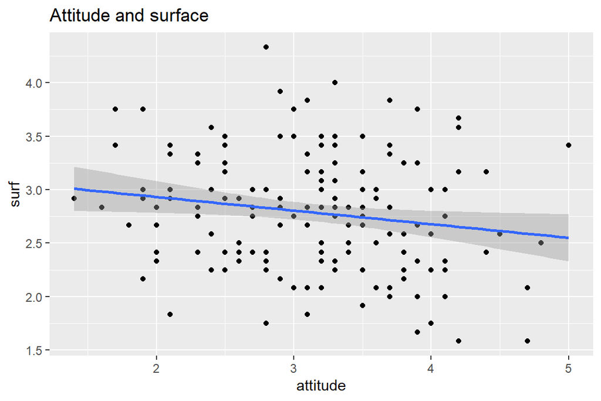

```r
ggplot(students2014, aes(x = attitude, y = surf)) +
  geom_point() +
  geom_smooth(method = "lm") +
  ggtitle("Attitude and surface")
```

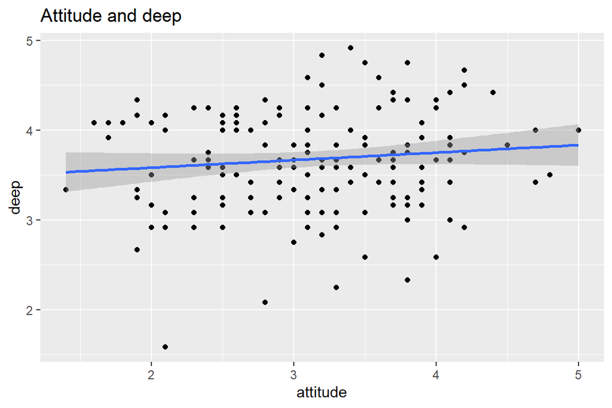

```r
ggplot(students2014, aes(x = attitude, y = deep)) +
  geom_point() +
  geom_smooth(method = "lm") +
  ggtitle("Attitude and deep")
```

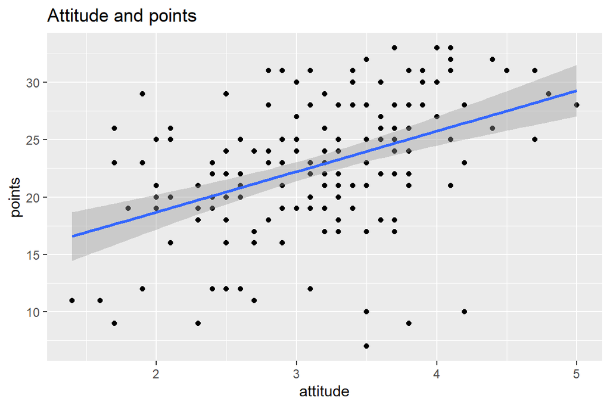

```r
ggplot(students2014, aes(x = attitude, y = points)) +
  geom_point() +
  geom_smooth(method = "lm") +
  ggtitle("Attitude and points")
```

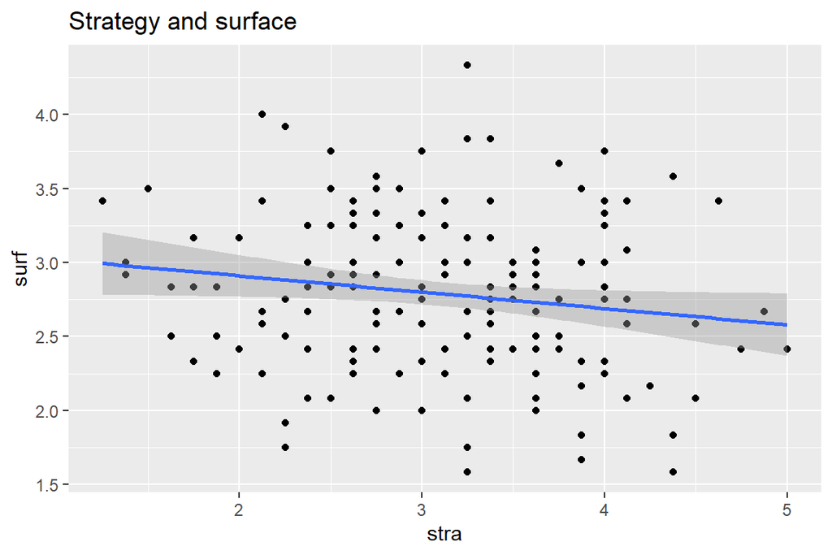

```r
ggplot(students2014, aes(x = stra, y = surf)) +
  geom_point() +
  geom_smooth(method = "lm") +
  ggtitle("Strategy and surface")
```

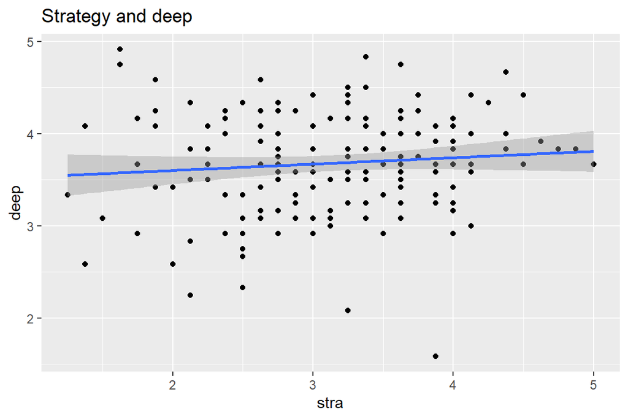

```r
ggplot(students2014, aes(x = stra, y = deep)) +
  geom_point() +
  geom_smooth(method = "lm") +
  ggtitle("Strategy and deep")
```

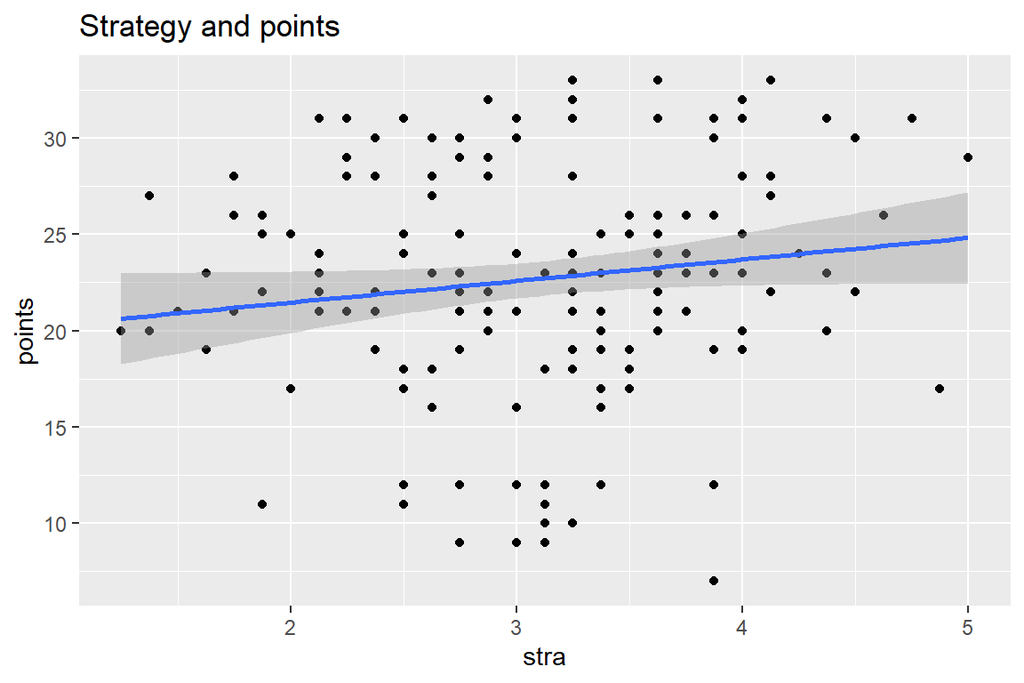

```r
ggplot(students2014, aes(x = stra, y = points)) +
  geom_point() +
  geom_smooth(method = "lm") +
  ggtitle("Strategy and points")
```

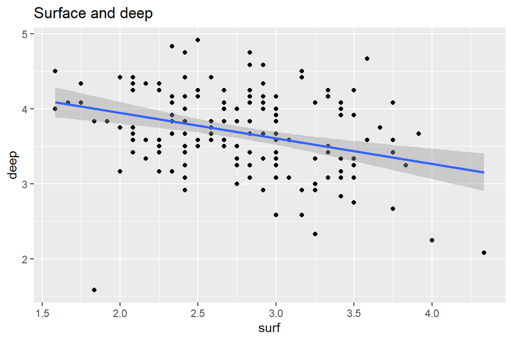

```r
ggplot(students2014, aes(x = surf, y = deep)) +
  geom_point() +
  geom_smooth(method = "lm") +
  ggtitle("Surface and deep")
```

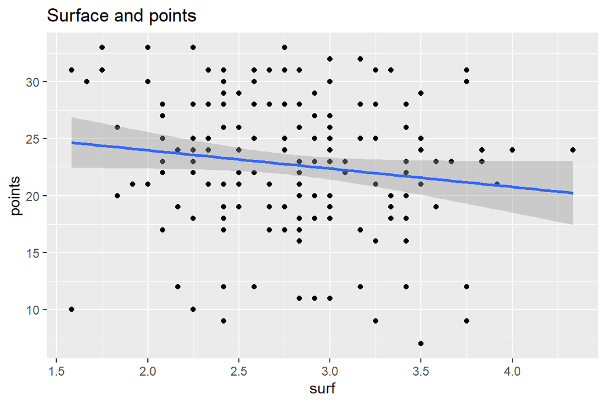

```r
ggplot(students2014, aes(x = surf, y = points)) +
  geom_point() +
  geom_smooth(method = "lm") +
  ggtitle("Surface and points")
```

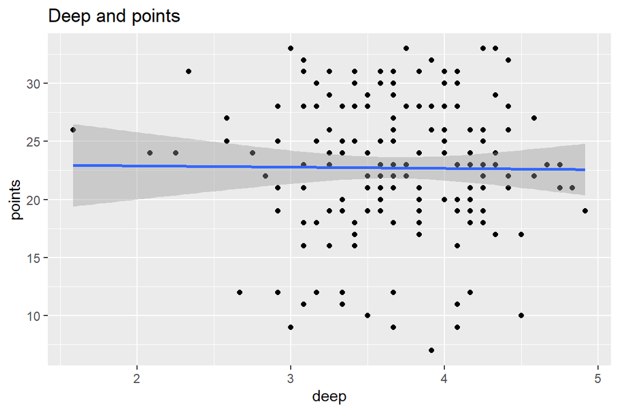

```r
ggplot(students2014, aes(x = deep, y = points)) +
  geom_point() +
  geom_smooth(method = "lm") +
  ggtitle("Deep and points")
```

```r
# Looking at the characteristics of the variables by taking their means, standard deviations, max values and min values

print("Mean, standard deviation, min and max of age")
```

```
## [1] "Mean, standard deviation, min and max of age"
```

```r
mean(students2014$age)
```

```
## [1] 25.51205
```

```r
sd(students2014$age)
```

```
## [1] 7.766078
```

```r
max(students2014$age)
```

```
## [1] 55
```

```r
min(students2014$age)
```

```
## [1] 17
```

```r
print("Mean, standard deviation, min and max of attitude")
```

```
## [1] "Mean, standard deviation, min and max of attitude"
```

```r
mean(students2014$attitude)
```

```
## [1] 3.142771
```

```r
sd(students2014$attitude)
```

```
## [1] 0.7299079
```

```r
max(students2014$attitude)
```

```
## [1] 5
```

```r
min(students2014$attitude)
```

```
## [1] 1.4
```

```r
print("Mean, standard deviation, max and min of deep")
```

```
## [1] "Mean, standard deviation, max and min of deep"
```

```r
mean(students2014$deep)
```

```
## [1] 3.679719
```

```r
sd(students2014$deep)
```

```
## [1] 0.5541369
```

```r
max(students2014$deep)
```

```
## [1] 4.916667
```

```r
min(students2014$deep)
```

```
## [1] 1.583333
```

```r
print("Mean, standard deviation, max and min of surface")
```

```
## [1] "Mean, standard deviation, max and min of surface"
```

```r
mean(students2014$surf)
```

```
## [1] 2.787149
```

```r
sd(students2014$surf)
```

```
## [1] 0.5288405
```

```r
max(students2014$surf)
```

```
## [1] 4.333333
```

```r
min(students2014$surf)
```

```
## [1] 1.583333
```

```r
print("Mean, standard deviation, max and min of strategy")
```

```
## [1] "Mean, standard deviation, max and min of strategy"
```

```r
mean(students2014$stra)
```

```
## [1] 3.121235
```

```r
sd(students2014$stra)
```

```
## [1] 0.7718318
```

```r
max(students2014$stra)
```

```
## [1] 5
```

```r
min(students2014$stra)
```

```
## [1] 1.25
```

```r
print("Mean, standard deviation, max and min of points")
```

```
## [1] "Mean, standard deviation, max and min of points"
```

```r
mean(students2014$points)
```

```
## [1] 22.71687
```

```r
sd(students2014$points)
```

```
## [1] 5.894884
```

```r
max(students2014$points)
```

```
## [1] 33
```

```r
min(students2014$points)
```

```
## [1] 7
```

```r
# To analyze gender variable, I first check how many male and female students are included in the data set
library(tidyverse)
count(students2014, gender)
```

```
##   gender   n
## 1      F 110
## 2      M  56
```

```r
# The output shows that there are 110 female students and 56 male students. To check whether there are differences in the variables between gender, I create separate data sets for female and male students and look at the means.
students_male <- filter(students2014, gender=="M")
students_female <- filter(students2014, gender=="F")

# Means of variables age, attitude, deep, surf, stra and poitns for males
mean(students_male$age)
```

```
## [1] 26.80357
```

```r
mean(students_male$attitude)
```

```
## [1] 3.442857
```

```r
mean(students_male$deep)
```

```
## [1] 3.724702
```

```r
mean(students_male$surf)
```

```
## [1] 2.703869
```

```r
mean(students_male$stra)
```

```
## [1] 2.964286
```

```r
mean(students_male$points)
```

```
## [1] 23.48214
```

```r
# Means of variables age, attitude, deep, surf, stra and points for females
mean(students_female$age)
```

```
## [1] 24.85455
```

```r
mean(students_female$attitude)
```

```
## [1] 2.99
```

```r
mean(students_female$deep)
```

```
## [1] 3.656818
```

```r
mean(students_female$surf)
```

```
## [1] 2.829545
```

```r
mean(students_female$stra)
```

```
## [1] 3.201136
```

```r
mean(students_female$points)
```

```
## [1] 22.32727
```

```r
# The output shows that male students have on average somewhat higher exam points compared to females (23.5 vs 22.3). Male students are on average 2 years older (27 yrs vs 25 yrs), males have on average higher attitude, while the other variables for males and females are fairly close.



# Looking at correlations of variables (excluding gender which is not a number)
students_cor <- students2014[-1]
cor(students_cor)
```

```
##                  age    attitude        deep        stra       surf      points
## age       1.00000000  0.02220071  0.02507804  0.10244409 -0.1414052 -0.09319032
## attitude  0.02220071  1.00000000  0.11024302  0.06174177 -0.1755422  0.43652453
## deep      0.02507804  0.11024302  1.00000000  0.09650255 -0.3238020 -0.01014849
## stra      0.10244409  0.06174177  0.09650255  1.00000000 -0.1609729  0.14612247
## surf     -0.14140516 -0.17554218 -0.32380198 -0.16097287  1.0000000 -0.14435642
## points   -0.09319032  0.43652453 -0.01014849  0.14612247 -0.1443564  1.00000000
```

```r
# The correlation matrix shows that for the most part correlation between the different variables is fairly low, between -0.2 and 0.2. There is a stronger positive correlation between points and attitude (0.44) and a negative correlation between deep and surf (-0.33)




# Part 3 and 4 of Assignment 2

# Regression model for exam points.

# As the first run of the regression model with 3 explanatory variables, I choose attitude, surface and strategy for the regression

model_points1 <- lm(points ~ attitude + stra + surf, data = students2014)

#printing the output of the regression model
model_points1
```

```
##
## Call:
## lm(formula = points ~ attitude + stra + surf, data = students2014)
##
## Coefficients:
## (Intercept)     attitude         stra         surf
##     11.0171       3.3952       0.8531      -0.5861
```

```r
summary(model_points1)
```

```
##
## Call:
## lm(formula = points ~ attitude + stra + surf, data = students2014)
##
## Residuals:
##      Min       1Q   Median       3Q      Max
## -17.1550  -3.4346   0.5156   3.6401  10.8952
##
## Coefficients:
##             Estimate Std. Error t value Pr(>|t|)
## (Intercept)  11.0171     3.6837   2.991  0.00322 **
## attitude      3.3952     0.5741   5.913 1.93e-08 ***
## stra          0.8531     0.5416   1.575  0.11716
## surf         -0.5861     0.8014  -0.731  0.46563
## ---
## Signif. codes:  0 '***' 0.001 '**' 0.01 '*' 0.05 '.' 0.1 ' ' 1
##
## Residual standard error: 5.296 on 162 degrees of freedom
## Multiple R-squared:  0.2074, Adjusted R-squared:  0.1927
## F-statistic: 14.13 on 3 and 162 DF,  p-value: 3.156e-08
```

```r
# Results of the first regression shows that attitude is statistically significant in explaining exam results. Strategy has some significance (t statistic 1.6) while surface is not significant. Statistical significance is evaluated by looking at the t values and P(>|t|) of the regression output.

# R-squared for the model1 is 0.193. Thus the three chosen variables explain less than 20 percent of the variability of exam points.

# The second regression takes out surf variable and adds age. The three explanatory variables are attitude, strategy and age.
model_points2 <- lm(points ~ attitude + stra + age, data = students2014)

#printing the output of the regression model
model_points2
```

```
##
## Call:
## lm(formula = points ~ attitude + stra + age, data = students2014)
##
## Coefficients:
## (Intercept)     attitude         stra          age
##    10.89543      3.48077      1.00371     -0.08822
```

```r
summary(model_points2)
```

```
##
## Call:
## lm(formula = points ~ attitude + stra + age, data = students2014)
##
## Residuals:
##      Min       1Q   Median       3Q      Max
## -18.1149  -3.2003   0.3303   3.4129  10.7599
##
## Coefficients:
##             Estimate Std. Error t value Pr(>|t|)
## (Intercept) 10.89543    2.64834   4.114 6.17e-05 ***
## attitude     3.48077    0.56220   6.191 4.72e-09 ***
## stra         1.00371    0.53434   1.878   0.0621 .
## age         -0.08822    0.05302  -1.664   0.0981 .
## ---
## Signif. codes:  0 '***' 0.001 '**' 0.01 '*' 0.05 '.' 0.1 ' ' 1
##
## Residual standard error: 5.26 on 162 degrees of freedom
## Multiple R-squared:  0.2182, Adjusted R-squared:  0.2037
## F-statistic: 15.07 on 3 and 162 DF,  p-value: 1.07e-08
```

```r
# Results of the second regression are better compared to first. Attitude is still statistically significant with t value of 6.1. This means that the hypothesis that the coefficient for attitude is zero can be rejected with high confidence. Strategy and age have moderate t values and can be rejected to be zero at somewhat lower 90 percent confidence.

# R-squared for the model2 is somewhat higher compared to the first regression at 0.204.

# Based on the regression output, one point higher attitude score would be expected to correspond to about 3.5 higher exam point, one point higher strategy score would correspond to 1.0 higher exam points, and one additional year of age would correspond to lower exam points by 0.1, thus marginally.

# Additionally, according to the regression results an average student for all the variables would be expected to have 22.7 exam points. An example student that performs one standard deviation above the mean across the variables would have an estimated exam points of 25.3. It should be noted this may not be a good illustration of a higher performing students as it assumes comparable high performance across all the three explanatory variables. An example student that performs one standard deviation below the mean across the variables would have an estimated exam points of 20.1.

estimated_points = 10.895 + 3.481*mean(students2014$attitude) + 1.004*mean(students2014$stra) -0.088*mean(students2014$age)
print(estimated_points)
```

```
## [1] 22.72365
```

```r
high_estimated_points = 10.895 + 3.481*(mean(students2014$attitude) + sd(students2014$attitude)) + 1.004*(mean(students2014$stra)+ sd(students2014$stra)) -0.088*(mean(students2014$age)+ sd(students2014$age))
print(high_estimated_points)
```

```
## [1] 25.35596
```

```r
low_estimated_points = 10.895 + 3.481*(mean(students2014$attitude) - sd(students2014$attitude)) + 1.004*(mean(students2014$stra) - sd(students2014$stra)) -0.088*(mean(students2014$age) - sd(students2014$age))
print(low_estimated_points)
```

```
## [1] 20.09133
```

```r
#Regressions for male and female students separately to assess whether there are meaningful differences
students_male <- filter(students2014, gender=="M")
students_female <- filter(students2014, gender=="F")

#Regression for males
model_points_male <- lm(points ~ attitude + stra + age, data = students_male)

#printing the output of the regression model
model_points_male
```

```
##
## Call:
## lm(formula = points ~ attitude + stra + age, data = students_male)
##
## Coefficients:
## (Intercept)     attitude         stra          age
##     12.9396       4.0108       0.3741      -0.1632
```

```r
summary(model_points_male)
```

```
##
## Call:
## lm(formula = points ~ attitude + stra + age, data = students_male)
##
## Residuals:
##      Min       1Q   Median       3Q      Max
## -17.7363  -3.1649   0.3247   2.8637   9.5794
##
## Coefficients:
##             Estimate Std. Error t value Pr(>|t|)
## (Intercept) 12.93956    4.92598   2.627 0.011298 *
## attitude     4.01082    1.13445   3.535 0.000865 ***
## stra         0.37413    0.91700   0.408 0.684956
## age         -0.16323    0.08559  -1.907 0.062029 .
## ---
## Signif. codes:  0 '***' 0.001 '**' 0.01 '*' 0.05 '.' 0.1 ' ' 1
##
## Residual standard error: 5.327 on 52 degrees of freedom
## Multiple R-squared:  0.2562, Adjusted R-squared:  0.2133
## F-statistic:  5.97 on 3 and 52 DF,  p-value: 0.001413
```

```r
#Regression for males
model_points_female <- lm(points ~ attitude + stra + age, data = students_female)

#printing the output of the regression model
model_points_female
```

```
##
## Call:
## lm(formula = points ~ attitude + stra + age, data = students_female)
##
## Coefficients:
## (Intercept)     attitude         stra          age
##     9.32567      3.29455      1.28794     -0.03911
```

```r
summary(model_points_female)
```

```
##
## Call:
## lm(formula = points ~ attitude + stra + age, data = students_female)
##
## Residuals:
##      Min       1Q   Median       3Q      Max
## -18.0261  -3.7124   0.7258   3.4651  10.7723
##
## Coefficients:
##             Estimate Std. Error t value Pr(>|t|)
## (Intercept)  9.32567    3.25957   2.861  0.00509 **
## attitude     3.29455    0.69763   4.722 7.17e-06 ***
## stra         1.28794    0.68486   1.881  0.06277 .
## age         -0.03911    0.06939  -0.564  0.57424
## ---
## Signif. codes:  0 '***' 0.001 '**' 0.01 '*' 0.05 '.' 0.1 ' ' 1
##
## Residual standard error: 5.268 on 106 degrees of freedom
## Multiple R-squared:  0.205,  Adjusted R-squared:  0.1825
## F-statistic: 9.112 on 3 and 106 DF,  p-value: 2.029e-05
```

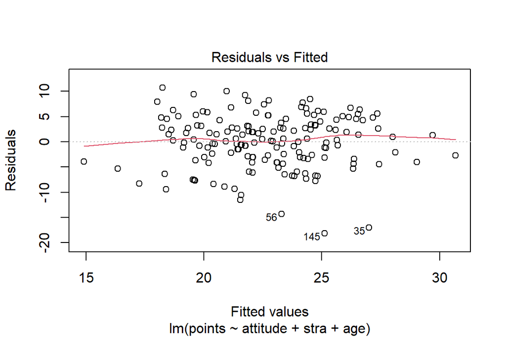

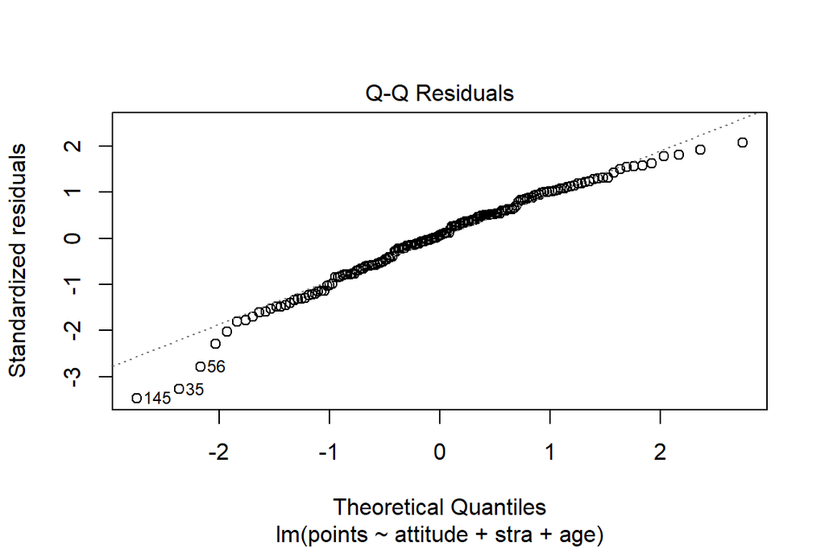

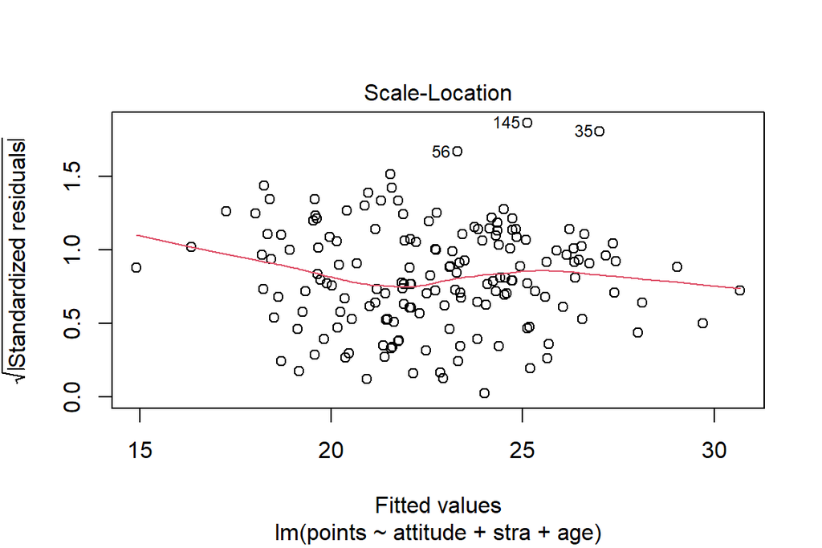

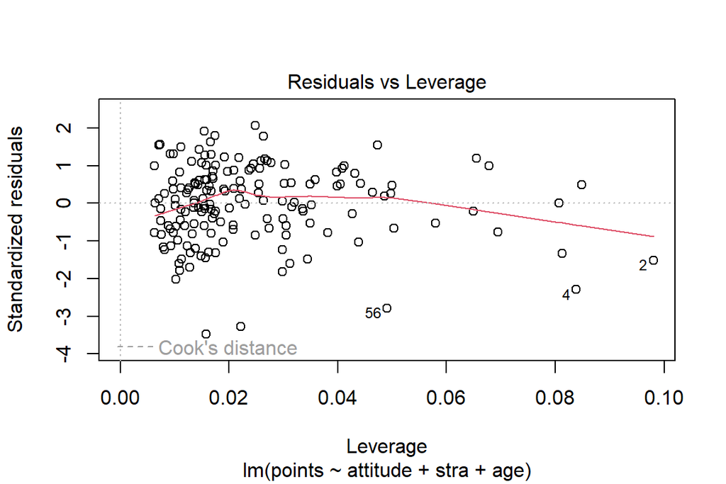

```r
# The separate regression models for do a better job in explaining variability of exam points for male students compared to female students (R-squared 0.21 vs 0.18).


#Part 5 of Assingment 2

# Diagnostic test are done with different regression diagnostic plots: regression vs fitted values, normal QQ-plot and residuals vs leverage.

plot(model_points2)
```

```r
# Residuals vs fitted values can be used to detect non-linearities, outliers or non-constant error variance. The scatter plot suggests that the residuals are scattered around 0 fairly randomly (linear relationship likely reasonable assumption) and there doesn't seem to be patterns suggesting changing error variance. However, there seems to be a few outliers with large negative residuals.

# Normal QQ-plot is used to assess if the residuals are normally distributed. If this is the case, the data points of the QQ-plot should be fairly closely aligned with a straight 45 degree line. Low and to extent high values for residuals seem to be off the straight line, suggesting that there may be a problem of outliers or fat-tails.

# Residuals vs levarage can be used to checked whether there are influential cases as not all outliers necessarily impact the regression line significantly. There doesn't see to be residuals to that breach the Cook's line (indication that there would be leverage)


date()
```

```
## [1] "Mon Dec 11 18:04:19 2023"
```

Here we go again…

# Chapter 3: Logistic regression

Each step of the assignment 3 is detailed below in the code section below.

Part 1: Reading and characterizing the data set

```r
# Reading the data file from the url link
alc <- read.table("https://raw.githubusercontent.com/KimmoVehkalahti/Helsinki-Open-Data-Science/master/datasets/alc.csv", sep = ",", header = T)

# Looking at the column names of the data set
colnames(alc)
```

```
##  [1] "school"     "sex"        "age"        "address"    "famsize"
##  [6] "Pstatus"    "Medu"       "Fedu"       "Mjob"       "Fjob"
## [11] "reason"     "guardian"   "traveltime" "studytime"  "schoolsup"
## [16] "famsup"     "activities" "nursery"    "higher"     "internet"
## [21] "romantic"   "famrel"     "freetime"   "goout"      "Dalc"
## [26] "Walc"       "health"     "failures"   "paid"       "absences"
## [31] "G1"         "G2"         "G3"         "alc_use"    "high_use"
```

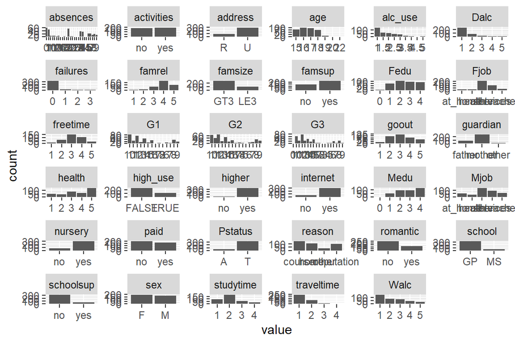

```r
# The data set includes 370 observations from 35 variables. The data set has been build by combining two data sets that include different variables of student achievement in secondary education of two Portuguese schools as well as different attributes, such as grades, demographic, social and school related features. Data set also includes variables for alcohol use, including an indicator for high and low usage.

library(ggplot2)
library(tidyverse)
library(readr)
library(dplyr)


# Using gather to draw a bar plot if each variable
gather(alc) %>% ggplot(aes(value)) + facet_wrap("key", scales = "free") + geom_bar()
```

Part 2: Analyzing the relationships between high/low alcohol consumption and some variables in the data

I have chosen four initial variables for the analysis: sex of the student (sex), number of school absences (absences), number of past class failures (failures), and quality of family relationships (famrel)

- Sex is used as a possible indicator for alcohol use with the assumption that boys/young men may be more prone to use alcohol. There seems to be some research showing that alcohol use of male students could be frequent.
- Number of school absences is chosen as a variable as alcohol use could be associated with problems in school leading to more absences. Using alcohol at a young age could also be correlated with some irresponsible behavior which could be related to absences.
- Failures in class is chosen with the hypothesis that students struggling in school may be more likely to use alcohol. This may be similar to absences, but there doesn’t seem to be clear correlation of absences and failures.
- Family relations could be an indicator of stability of home life for student. Worse family relations could mean that the student spends more time out of the home (getting in to trouble and possible using alcohol) and has less support to deal with issues.

```r
library(tidyr); library(dplyr); library(ggplot2)

# Looking at some characteristics of the chosen variables
count(alc, sex)
```

```
##   sex   n
## 1   F 195
## 2   M 175
```

```r
mean(alc$absences)
```

```
## [1] 4.510811
```

```r
mean(alc$failures)
```

```
## [1] 0.1891892
```

```r
mean(alc$famrel)
```

```
## [1] 3.935135
```

```r
alc_male <- filter(alc, sex=="M")
alc_female <- filter(alc, sex=="F")
mean(alc_male$alc_use)
```

```
## [1] 2.191429
```

```r
mean(alc_female$alc_use)
```

```
## [1] 1.617949
```

```r
mean(alc_male$absences)
```

```
## [1] 4.188571
```

```r
mean(alc_female$absences)
```

```
## [1] 4.8
```

```r
mean(alc_male$failures)
```

```
## [1] 0.24
```

```r
mean(alc_female$failures)
```

```
## [1] 0.1435897
```

```r
mean(alc_male$famrel)
```

```
## [1] 3.994286
```

```r
mean(alc_female$famrel)
```

```
## [1] 3.882051
```

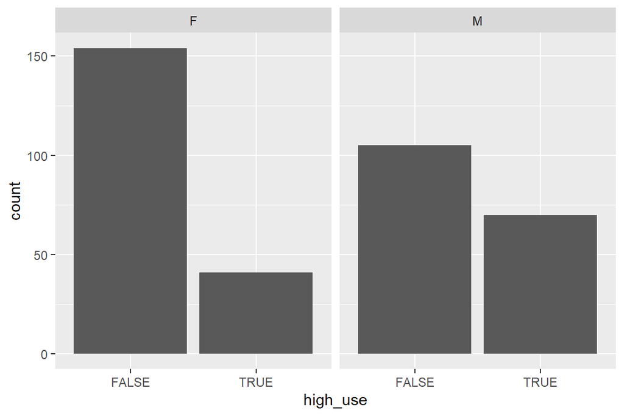

```r
# Taking first a look at alcohol use by sex
ggplot(alc,  aes(x = high_use)) + geom_bar() + facet_wrap("sex")
```

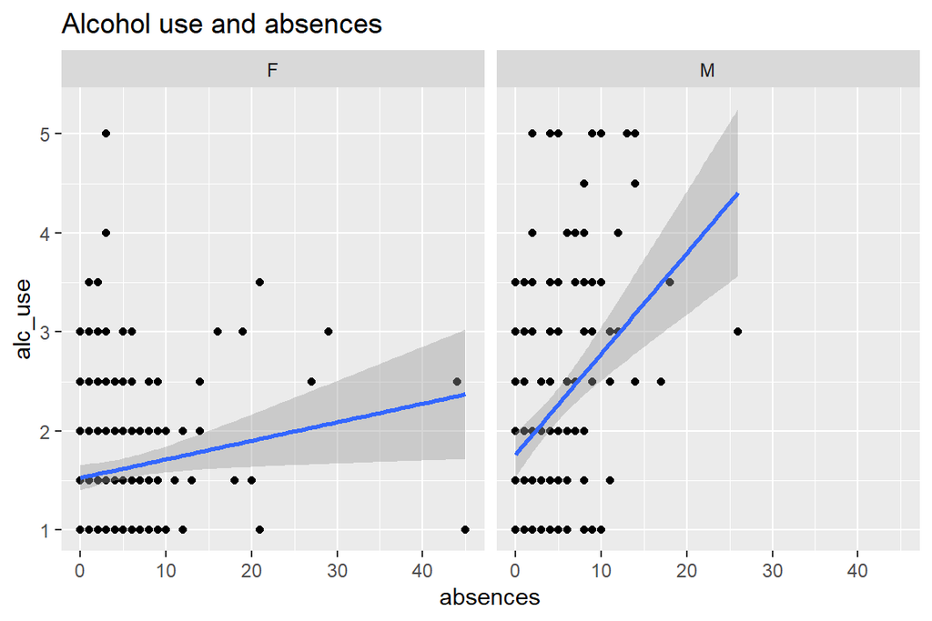

```r
# The graph shows that the share of high alcohol use is higher for male students compared to female students

# Looking at relation between alc_use and absences by sex
ggplot(alc, aes(x = absences, y = alc_use)) + geom_point() + geom_smooth(method = "lm") + facet_wrap("sex") + ggtitle("Alcohol use and absences")
```

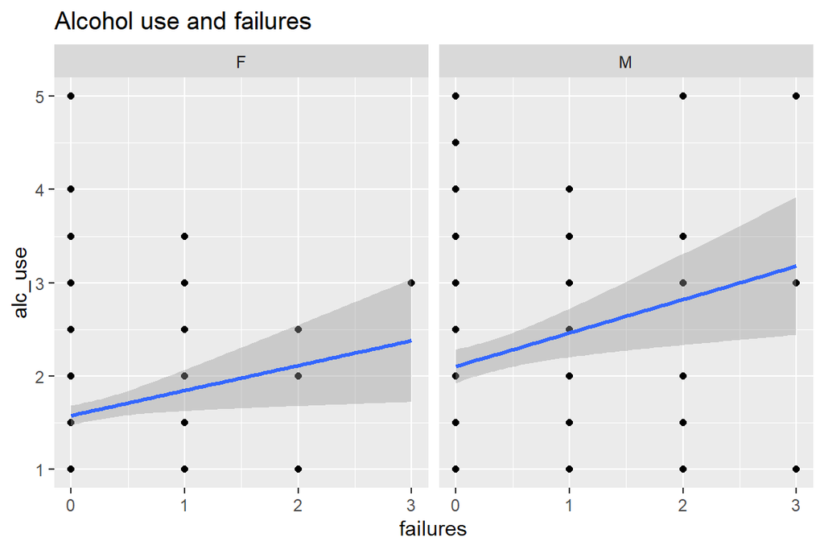

```r
# Based on visual assessment of the graph, there seems to be a positive relation between absences and alcohol use. The relation seems much stronger for male students.

# Looking at relation between alc_use and failures by sex
ggplot(alc, aes(x = failures, y = alc_use)) + geom_point() + geom_smooth(method = "lm") + facet_wrap("sex") + ggtitle("Alcohol use and failures")
```

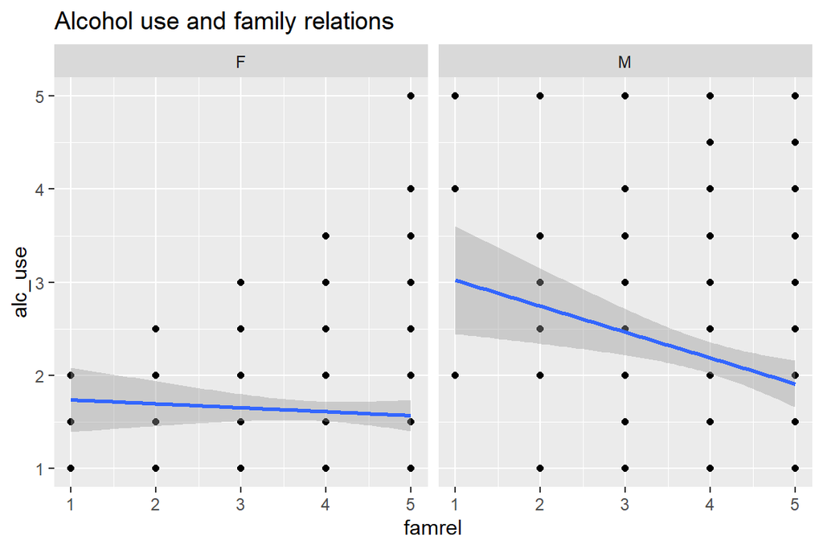

```r
# Based on visual assessment of the graph, there seems to be a positive relation between failures in school and alcohol use.

# Looking at relation between alc_use and famrel by sex
ggplot(alc, aes(x = famrel, y = alc_use)) + geom_point() + geom_smooth(method = "lm") + facet_wrap("sex") + ggtitle("Alcohol use and family relations")
```